# Biostat 212a Homework 2

Due Feb 6, 2024 @ 11:59PM

Author

Li Zhang 206305918

Published

February 6, 2024

## 1 ISL Exercise 4.8.1 (10pts)

(4.2):
$$p(X) = \frac{e^{\beta_0+\beta_1 X}}{1 + e^{\beta_0+\beta_1 X}}$$

(4.3):
$$\frac{p(X)}{1 - p(X)} = e^{\beta_0 + \beta_1 X}$$

To prove (4.2) and (4.3) are equal,

we can regard $e^{\beta_0+\beta_1 X}$ as a new variable $Z$, then (4.2) can be rewrote as $Z = p(X)(1+Z)$,

so $Z=\frac{p(X)}{1-p(X)}$, which is the same as (4.3).

## 2 ISL Exercise 4.8.6 (10pts)

1. According to (4.2), we know that
   $$p(X) = \frac{e^{\hat{\beta}_0+\hat{\beta}_1 X_1+\hat{\beta}_2 X_2}}{1 + e^{\hat{\beta}_0+\hat{\beta}_1 X_1+\hat{\beta}_2 X_2}}$$

So,
$$p(X) = \frac{e^{-6+0.05*40+1*3.5}}{1 + e^{-6+0.05*40+1*3.5}} = 0.3775407$$

So the probability that a student who studies for 40 hours and has an undergrad GPA of 3.5 gets an A in the class is **0.3775407**.

2. using $p(X) = 0.5$ in above equation (a) we have
   $$0.5 = \frac{e^{-6+0.05X_1+1*3.5}}{1 + e^{-6+0.05X_1+1*3.5}}\\$$

so,

$$e^{-6+0.05X_1+1*3.5} = 1$$
$$-6+0.05X_1+1*3.5 = 0$$
$$0.05X_1 = 6-3.5$$
$$X_1 = 50$$
the student in part (a) need to study **50 hours** to have a 50% chance of getting an A in the class.

## 3 ISL Exercise 4.8.9 (10pts)

1. we know that
   $$odds = \frac{p(X)}{1-p(X)}$$
   so, when odds = 0.37, we have
   $$0.37 = \frac{p(X)}{1-p(X)}$$

$$p(X) = 0.27$$

27% of the people will default when the odds of default is 0.37.

2. when $p(X) = 0.16$, we have
   $$odds = \frac{p(X)}{1-p(X)} = \frac{0.16}{1-0.16} = 0.19$$

so the odds of default is 0.19 when the probability of default is 0.16.

## 4 ISL Exercise 4.8.13 (a)-(i) (50pts)

```r
library(ISLR2)
str(Weekly)
```

```
'data.frame':   1089 obs. of  9 variables:
 $ Year     : num  1990 1990 1990 1990 1990 1990 1990 1990 1990 1990 ...
 $ Lag1     : num  0.816 -0.27 -2.576 3.514 0.712 ...
 $ Lag2     : num  1.572 0.816 -0.27 -2.576 3.514 ...
 $ Lag3     : num  -3.936 1.572 0.816 -0.27 -2.576 ...
 $ Lag4     : num  -0.229 -3.936 1.572 0.816 -0.27 ...
 $ Lag5     : num  -3.484 -0.229 -3.936 1.572 0.816 ...
 $ Volume   : num  0.155 0.149 0.16 0.162 0.154 ...
 $ Today    : num  -0.27 -2.576 3.514 0.712 1.178 ...
 $ Direction: Factor w/ 2 levels "Down","Up": 1 1 2 2 2 1 2 2 2 1 ...
```

```r
head(Weekly)
```

```
  Year   Lag1   Lag2   Lag3   Lag4   Lag5    Volume  Today Direction
1 1990  0.816  1.572 -3.936 -0.229 -3.484 0.1549760 -0.270      Down
2 1990 -0.270  0.816  1.572 -3.936 -0.229 0.1485740 -2.576      Down
3 1990 -2.576 -0.270  0.816  1.572 -3.936 0.1598375  3.514        Up
4 1990  3.514 -2.576 -0.270  0.816  1.572 0.1616300  0.712        Up
5 1990  0.712  3.514 -2.576 -0.270  0.816 0.1537280  1.178        Up
6 1990  1.178  0.712  3.514 -2.576 -0.270 0.1544440 -1.372      Down
```

```r
summary(Weekly)
```

```
      Year           Lag1               Lag2               Lag3
 Min.   :1990   Min.   :-18.1950   Min.   :-18.1950   Min.   :-18.1950
 1st Qu.:1995   1st Qu.: -1.1540   1st Qu.: -1.1540   1st Qu.: -1.1580
 Median :2000   Median :  0.2410   Median :  0.2410   Median :  0.2410
 Mean   :2000   Mean   :  0.1506   Mean   :  0.1511   Mean   :  0.1472
 3rd Qu.:2005   3rd Qu.:  1.4050   3rd Qu.:  1.4090   3rd Qu.:  1.4090
 Max.   :2010   Max.   : 12.0260   Max.   : 12.0260   Max.   : 12.0260
      Lag4               Lag5              Volume            Today
 Min.   :-18.1950   Min.   :-18.1950   Min.   :0.08747   Min.   :-18.1950
 1st Qu.: -1.1580   1st Qu.: -1.1660   1st Qu.:0.33202   1st Qu.: -1.1540
 Median :  0.2380   Median :  0.2340   Median :1.00268   Median :  0.2410
 Mean   :  0.1458   Mean   :  0.1399   Mean   :1.57462   Mean   :  0.1499
 3rd Qu.:  1.4090   3rd Qu.:  1.4050   3rd Qu.:2.05373   3rd Qu.:  1.4050
 Max.   : 12.0260   Max.   : 12.0260   Max.   :9.32821   Max.   : 12.0260
 Direction
 Down:484
 Up  :605
```

```r
cor(Weekly[-9])
```

```
              Year         Lag1        Lag2        Lag3         Lag4
Year    1.00000000 -0.032289274 -0.03339001 -0.03000649 -0.031127923
Lag1   -0.03228927  1.000000000 -0.07485305  0.05863568 -0.071273876
Lag2   -0.03339001 -0.074853051  1.00000000 -0.07572091  0.058381535
Lag3   -0.03000649  0.058635682 -0.07572091  1.00000000 -0.075395865
Lag4   -0.03112792 -0.071273876  0.05838153 -0.07539587  1.000000000
Lag5   -0.03051910 -0.008183096 -0.07249948  0.06065717 -0.075675027
Volume  0.84194162 -0.064951313 -0.08551314 -0.06928771 -0.061074617
Today  -0.03245989 -0.075031842  0.05916672 -0.07124364 -0.007825873
               Lag5      Volume        Today
Year   -0.030519101  0.84194162 -0.032459894
Lag1   -0.008183096 -0.06495131 -0.075031842
Lag2   -0.072499482 -0.08551314  0.059166717
Lag3    0.060657175 -0.06928771 -0.071243639
Lag4   -0.075675027 -0.06107462 -0.007825873
Lag5    1.000000000 -0.05851741  0.011012698
Volume -0.058517414  1.00000000 -0.033077783
Today   0.011012698 -0.03307778  1.000000000
```

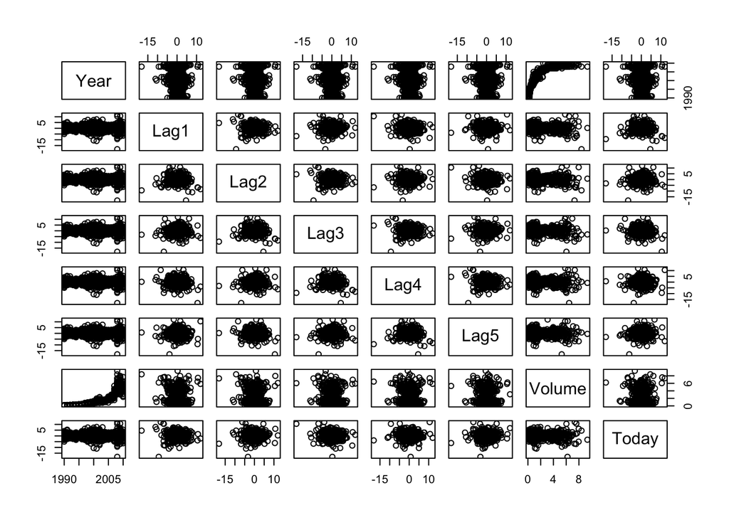

```r
library(GGally)
pairs(~ Year + Lag1 + Lag2 + Lag3 + Lag4 + Lag5 + Volume + Today, Weekly)
```

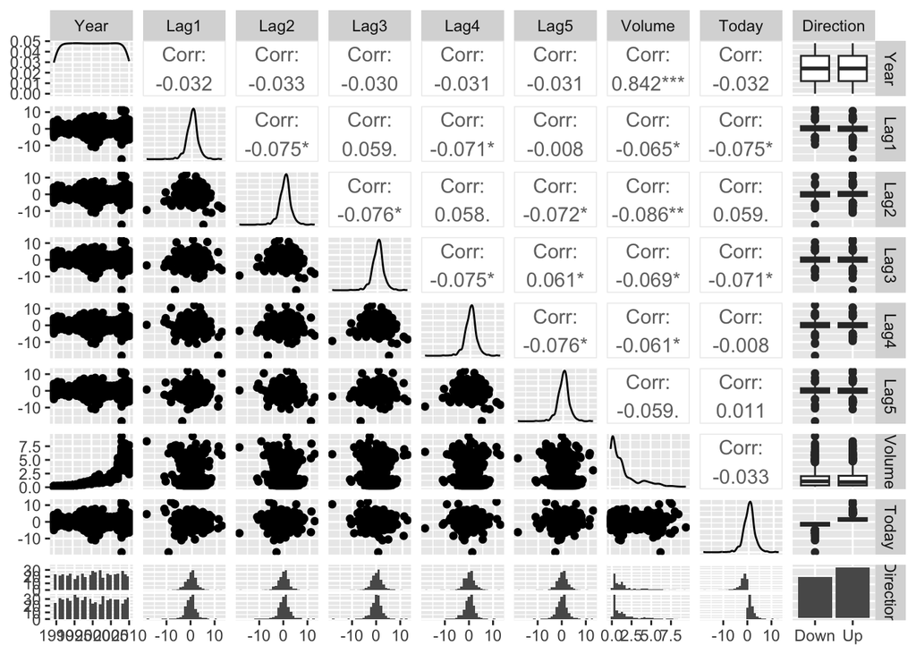

```r
ggpairs(Weekly)
```

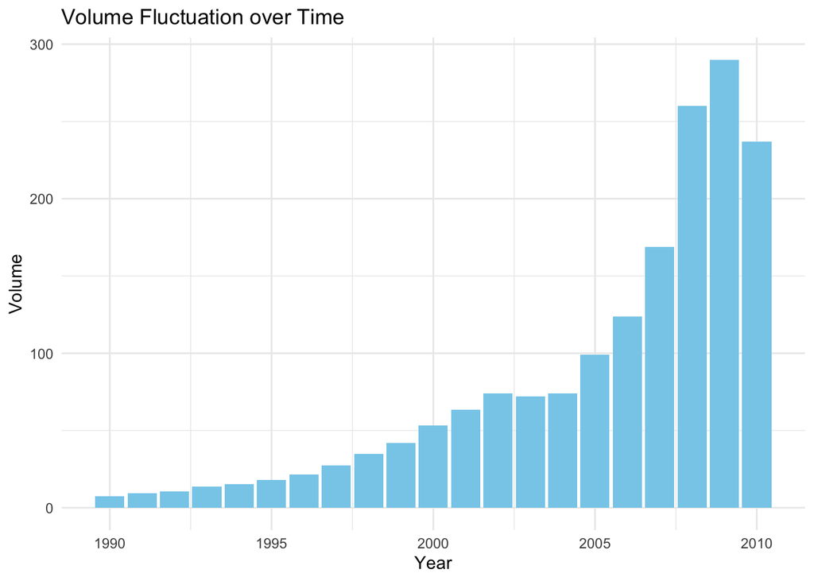

```r
# Create volume bar chart
library(ggplot2)
ggplot(data = Weekly, aes(x = Year, y = Volume)) +
  geom_bar(stat = "identity", fill = "skyblue") +
  labs(title = "Volume Fluctuation over Time", x = "Year", y = "Volume") +
  theme_minimal()
```

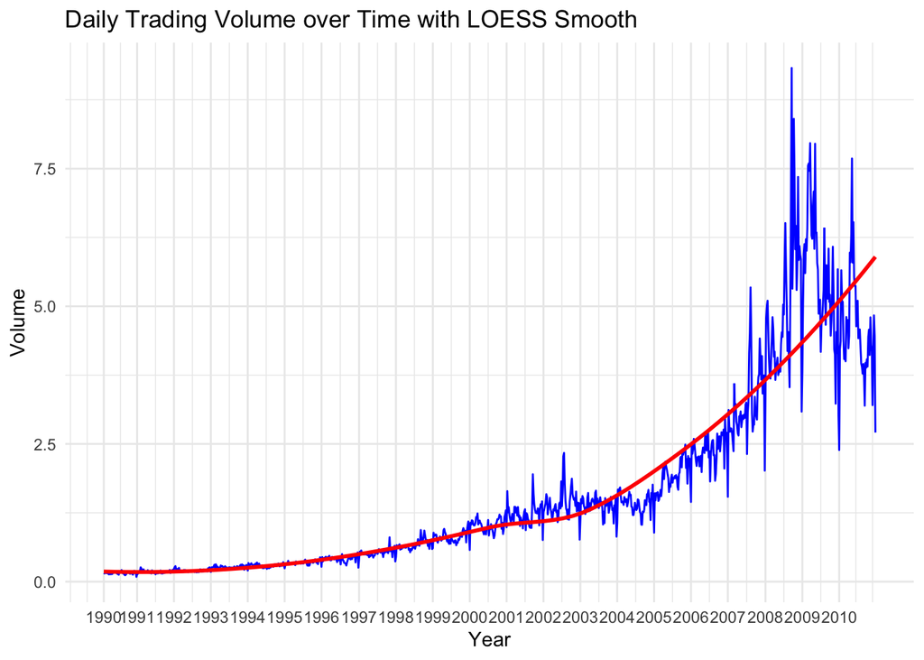

```r
library(ggplot2)
library(dplyr)

# Add a column for week of the year
Weekly$Week <- 1:nrow(Weekly)

# Group data by year and get the first week of each year
year_breaks <- Weekly %>%
  group_by(Year) %>%
  summarize(Week = min(Week))

# Daily Trading Volume over Time with LOESS Smooth
p1 <- ggplot(Weekly, aes(x = Week, y = Volume)) +
  geom_line(color = "blue") +
  geom_smooth(method = "loess", se = FALSE, color = "red") +
  scale_x_continuous(breaks = year_breaks$Week, labels = year_breaks$Year) +
  labs(title = "Daily Trading Volume over Time with LOESS Smooth", x = "Year", y = "Volume") +
  theme_minimal()
print(p1)
```

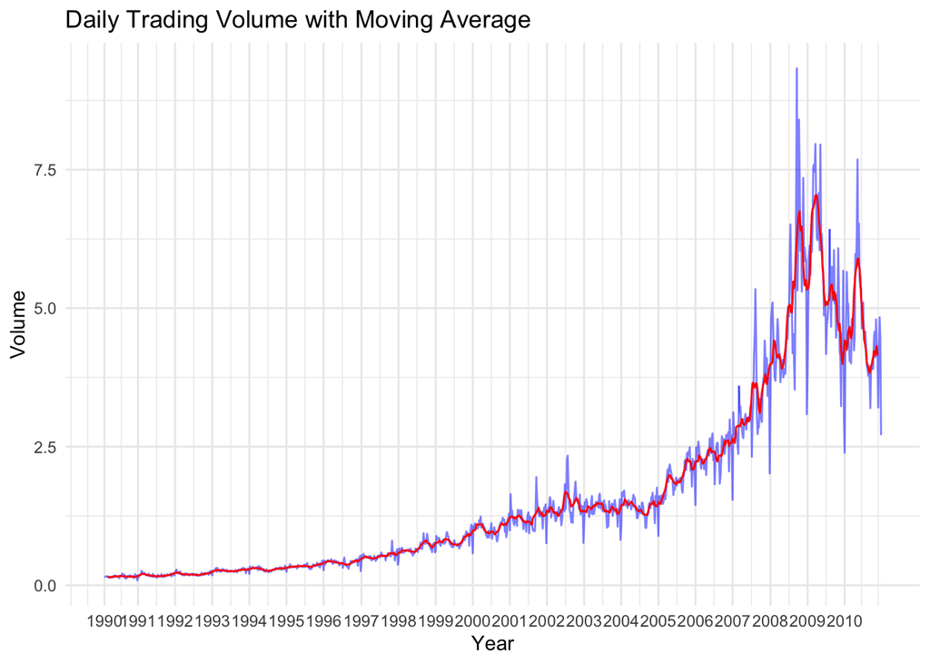

```r
# Daily Trading Volume with Moving Average
Weekly$Moving_Average <- zoo::rollmean(Weekly$Volume, k = 10, fill = NA)

p2 <- ggplot(Weekly, aes(x = Week)) +
  geom_line(aes(y = Volume), color = "blue", alpha = 0.5) +
  geom_line(aes(y = Moving_Average), color = "red") +
  scale_x_continuous(breaks = year_breaks$Week, labels = year_breaks$Year) +
  labs(title = "Daily Trading Volume with Moving Average", x = "Year", y = "Volume") +
  theme_minimal()
print(p2)
```

```r
prop.table(table(Weekly$Direction))
```

```
     Down        Up
0.4444444 0.5555556
```

The daily trading volume of shares has exhibited an upward trend over time, punctuated by occasional fluctuations.

Since the 1990s, there has been a notable surge in the trading volume of shares. This trend reached its highest point around 2009, but began to decline starting from 2010, probably due to the financial crisis in 2008.

The proportion of the market going up is 55.56% and the proportion of the market going down is 44.44%.

```r
glm.fit <- glm(Direction ~ Lag1 + Lag2 + Lag3 + Lag4 + Lag5 + Volume,
               data = Weekly,
               family = binomial)
summary(glm.fit)
```

```
Call:
glm(formula = Direction ~ Lag1 + Lag2 + Lag3 + Lag4 + Lag5 +
    Volume, family = binomial, data = Weekly)

Coefficients:
            Estimate Std. Error z value Pr(>|z|)
(Intercept)  0.26686    0.08593   3.106   0.0019 **
Lag1        -0.04127    0.02641  -1.563   0.1181
Lag2         0.05844    0.02686   2.175   0.0296 *
Lag3        -0.01606    0.02666  -0.602   0.5469
Lag4        -0.02779    0.02646  -1.050   0.2937
Lag5        -0.01447    0.02638  -0.549   0.5833
Volume      -0.02274    0.03690  -0.616   0.5377
---
Signif. codes:  0 '***' 0.001 '**' 0.01 '*' 0.05 '.' 0.1 ' ' 1

(Dispersion parameter for binomial family taken to be 1)

    Null deviance: 1496.2  on 1088  degrees of freedom
Residual deviance: 1486.4  on 1082  degrees of freedom
AIC: 1500.4

Number of Fisher Scoring iterations: 4
```

Lag2 is statistically significant at the 5% level.

```r
glm.prob <- predict(glm.fit, type = 'response')
glm.pred <- rep('Down',1089)
glm.pred[glm.prob > 0.5] <- 'Up'
table(glm.pred, Weekly[, "Direction"])
```

```
glm.pred Down  Up
    Down   54  48
    Up    430 557
```

$$Accuracy = \frac{TP+TN}{TP+FP+FN+TN} = \frac{557+54}{557+54+48+430} = 0.5610652$$

Overall fraction of correct predictions is 0.5611.

Types of Mistakes Made by Logistic Regression as Indicated by the Confusion Matrix:

- False Positives(FP):

The model incorrectly predicted 430 instances of the “Down” class as “Up”. This suggests that the model may be overly optimistic or sensitive in certain situations, incorrectly predicting instances of actual decreases as increases.

- False Negatives(FN):

The model incorrectly predicted 48 instances of the “Up” class as “Down”. This indicates that the model may have missed some important patterns or features in certain situations, incorrectly predicting instances of actual increases as decreases.

```r
training_data <- subset(Weekly, Year <= 2008)
held_out_data <- subset(Weekly, Year >= 2009)

logit_model <- glm(Direction ~ Lag2, data = training_data, family = binomial)

predicted_probs <- predict(logit_model, newdata = held_out_data, type = "response")

predicted_classes <- ifelse(predicted_probs > 0.5, "Up", "Down")

confusion_matrix <- table(predicted_classes, held_out_data$Direction)
print(confusion_matrix)
```

```
predicted_classes Down Up
             Down    9  5
             Up     34 56
```

$$Accuracy = \frac{TP+TN}{TP+FP+FN+TN} = \frac{56+9}{56+9+34+5} = 0.625$$

Overall fraction of correct predictions for the held out data is 0.625.

```r
library(MASS)

# Fit the LDA model using Lag2 as the predictor
lda_model <- lda(Direction ~ Lag2, data = training_data)

predicted_classes_lda <- predict(lda_model, newdata = held_out_data)$class

confusion_matrix_lda <- table(predicted_classes_lda, held_out_data$Direction)
print(confusion_matrix_lda)
```

```
predicted_classes_lda Down Up
                 Down    9  5
                 Up     34 56
```

```r
sum(diag(confusion_matrix_lda)) / sum(confusion_matrix_lda)
```

```
[1] 0.625
```

Overall Accuracy (LDA): 0.625

```r
# Fit the QDA model using Lag2 as the predictor
qda_model <- qda(Direction ~ Lag2, data = training_data)

predicted_classes_qda <- predict(qda_model, newdata = held_out_data)$class

confusion_matrix_qda <- table(predicted_classes_qda, held_out_data$Direction)
print(confusion_matrix_qda)
```

```
predicted_classes_qda Down Up
                 Down    0  0
                 Up     43 61
```

```r
sum(diag(confusion_matrix_qda)) / sum(confusion_matrix_qda)
```

```
[1] 0.5865385
```

Overall Accuracy (QDA): 0.5865385

```r
library(class)
library(caret)
# Fit the KNN model using Lag2 as the predictor
set.seed(1)
predicted_knn <- knn(train = data.frame(Lag2 = training_data$Lag2),
                  test = data.frame(Lag2 = held_out_data$Lag2),
                  cl = training_data$Direction,
                  k = 1,
                  prob = T)

confusionMatrix(data = predicted_knn,
                reference = held_out_data$Direction,
                positive = "Up")
```

```
Confusion Matrix and Statistics

          Reference
Prediction Down Up
      Down   21 30
      Up     22 31

               Accuracy : 0.5
                 95% CI : (0.4003, 0.5997)
    No Information Rate : 0.5865
    P-Value [Acc > NIR] : 0.9700

                  Kappa : -0.0033

 Mcnemar's Test P-Value : 0.3317

            Sensitivity : 0.5082
            Specificity : 0.4884
         Pos Pred Value : 0.5849
         Neg Pred Value : 0.4118
             Prevalence : 0.5865
         Detection Rate : 0.2981
   Detection Prevalence : 0.5096
      Balanced Accuracy : 0.4983

       'Positive' Class : Up
```

The KNN model has an overall accuracy of 0.5

```r
library(e1071)

# Fit the Naive Bayes model using Lag2 as the predictor
nb_model <- naiveBayes(Direction ~ Lag2, data = training_data)

nb_pred <- predict(nb_model, newdata = held_out_data, type = "class")

conf_matrix_nb <- table(Actual_Direction = held_out_data$Direction, Predicted_Direction = nb_pred)
print(conf_matrix_nb)
```

```
                Predicted_Direction
Actual_Direction Down Up
            Down    0 43
            Up      0 61
```

```r
sum(diag(conf_matrix_nb)) / sum(conf_matrix_nb)
```

```
[1] 0.5865385
```

Overall Accuracy (Naive Bayes): 0.5865385

LDA & Logistic Regression have the highest accuracy of 0.625 after comparing the accuracy of all the models.

## 5 Bonus question: ISL Exercise 4.8.13 Part (j) (30pts)

```r
library(caret)

training_data$Today <- NULL
training_data$Moving_Average <- NULL

ctrl <- trainControl(method = "repeatedcv",
                     number = 5,
                     repeats = 5)

set.seed(111)

knn_train <- train(y = training_data$Direction,
                   x = training_data[ ,-8],
                   method = "knn",
                   metric = "Accuracy",
                   preProcess = c("center", "scale"),
                   tuneGrid = expand.grid(k = seq(1, 100, 2)),
                   trControl = ctrl)

caret::varImp(knn_train)
```

```
ROC curve variable importance

       Importance
Lag1      100.000
Lag2       77.256
Lag5       64.309
Year       45.659
Volume     43.735
Week       42.513
Lag4        4.578
Lag3        0.000
```

```r
knn_train
```

```
k-Nearest Neighbors

985 samples
  8 predictor
  2 classes: 'Down', 'Up'

Pre-processing: centered (8), scaled (8)
Resampling: Cross-Validated (5 fold, repeated 5 times)
Summary of sample sizes: 788, 788, 788, 788, 788, 787, ...
Resampling results across tuning parameters:

  k   Accuracy   Kappa
   1  0.4947996  -0.0207561478
   3  0.5230447   0.0309220921
   5  0.5230292   0.0287693723
```

[output cut: 50 more lines]

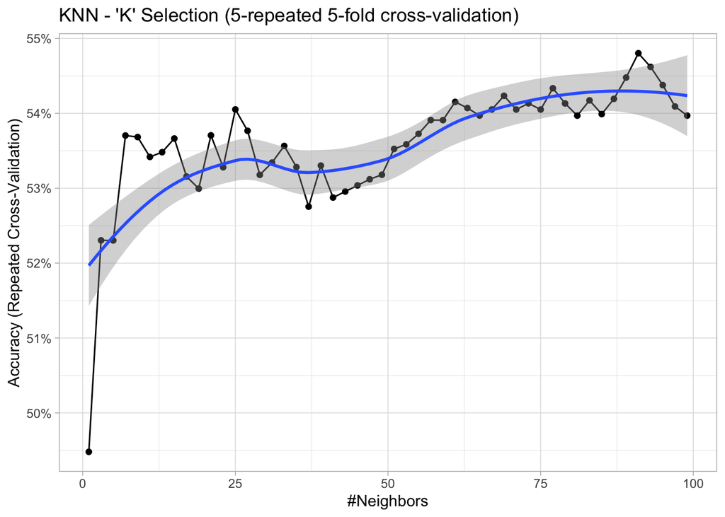

```r
ggplot(knn_train) +
  geom_smooth() +
  theme_light() +
  scale_y_continuous(labels = scales::percent_format()) +
  ggtitle("KNN - 'K' Selection (5-repeated 5-fold cross-validation)")
```

```r
knn_pred <- predict(knn_train, newdata = held_out_data)

confusionMatrix(data = knn_pred,
                reference = held_out_data$Direction,
                positive = "Up")
```

```
Confusion Matrix and Statistics

          Reference
Prediction Down Up
      Down    3  4
      Up     40 57

               Accuracy : 0.5769
                 95% CI : (0.4761, 0.6732)
    No Information Rate : 0.5865
    P-Value [Acc > NIR] : 0.6193

                  Kappa : 0.0048

 Mcnemar's Test P-Value : 1.317e-07

            Sensitivity : 0.93443
            Specificity : 0.06977
         Pos Pred Value : 0.58763
         Neg Pred Value : 0.42857
             Prevalence : 0.58654
         Detection Rate : 0.54808
   Detection Prevalence : 0.93269
      Balanced Accuracy : 0.50210

       'Positive' Class : Up
```

the accuracy of the KNN model is 0.5769, which is a little higher than the KNN model in part (g).

## 6 Bonus question: ISL Exercise 4.8.4 (30pts)

Given that $X$ is uniformly distributed on the interval$[0, 1]$, the range of $X$ closest to a test observation with$X = x$will be $[x - 0.1x, x + 0.1x] = [0.9x, 1.1x]$.

the fraction of available observations that will be used to make the prediction for a given test observation with $X = x$ is:

$$\frac{1.1x - 0.9x}{1-0} = 0.2x$$

To find the average fraction of observations used across all possible values of $X$, we integrate this expression over the range of $X$:

$$\int_{0}^{1} 0.2x dx = 0.2 \int_{0}^{1} x dx = 0.2 \left[\frac{x^2}{2}\right]_{0}^{1} = 0.2 \left[\frac{1^2}{2} - \frac{0^2}{2}\right] = 0.2 \times 0.5 = 0.1$$

So, on average, 10% of the available observations will be used to make the prediction for a given test observation.

Similarly, given that $(X_1, X_2)$ are uniformly distributed on the interval $[0, 1] × [0, 1]$, the range of $X_1$ closest to a test observation with $X_1 = x_1$ will be $[x_1 - 0.1x_1, x_1 + 0.1x_1] = [0.9x_1, 1.1x_1]$, and the range of $X_2$ closest to a test observation with $X_2 = x_2$ will be $[0.9x_2, 1.1x_2]$.

The fraction of available observations that will be used to make the prediction for a given test observation with $(X_1, X_2) = (x_1, x_2)$ is:

$$\frac{1.1x_1 - 0.9x_1}{1-0} \times \frac{1.1x_2 - 0.9x_2}{1-0} = 0.2x_1 \times 0.2x_2 = 0.04x_1x_2$$

To find the average fraction of observations used across all possible values of $(X_1, X_2)$, we integrate this expression over the range of $X_1$ and $X_2$:

$$\int_{0}^{1} \int_{0}^{1} 0.04x_1x_2 dx_1 dx_2 = 0.04 \int_{0}^{1} x_2 dx_2 \int_{0}^{1} x_1 dx_1 = 0.04 \left[\frac{x_2^2}{2}\right]_{0}^{1} \left[\frac{x_1^2}{2}\right]_{0}^{1} = 0.04 \times 0.5 \times 0.5 = 0.01$$

So, on average, 1% of the available observations will be used to make the prediction for a given test observation.

Using identical reasoning to part (b), when $p = 100$, $0.1^{100}$ of the available observations will be used to make the prediction.

When p is large, the fraction of available observations that will be used to make the prediction for a given test observation is $0.1^p$.

As p increases, this fraction decreases exponentially. This means that as p increases, the number of training observations “near” any given test observation decreases exponentially.

This is a drawback of KNN when p is large because the prediction for a given test observation will be based on a very small number of training observations, which may not be sufficient to make an accurate prediction.

If $p=1$, $d(length) = 0.1^{1/1} = 0.1$

If $p=2$, $d(length) = 0.1^{1/2} = 0.32$

If $p=100$, $d(length) = 0.1^{1/100} = 0.977$

As p increases the side length converges to 1, and this shows that the hypercube centered around the test observation with 10% of the test observation needs to be nearly the same size as the hypercube with all the observations.

It also shows that observations are ‘further’ from a test observation as p increases; that is they are concentrated near the boundary of the hypercube.